# Getting started with deaviz

`deaviz` turns the numbers behind a Data Envelopment Analysis (DEA), whether they are input/output profiles or the computational outcomes of various DEA models, into plots of efficiency distributions, input/output relationships, efficient frontier representations, projection biplots, benchmarking networks, cross-efficiency maps, and multi-period trajectories for panel data. This vignette walks through a typical workflow using two bundled datasets.

The workflow has three steps that map onto the package’s naming convention:

1. wrap your data in a **`dea_data()`** object (inputs, outputs, DMU labels);
2. **`compute_*()`** the quantities you need (efficiency, cross-efficiency, weights, self-organising maps);
3. **`plot_*()`** the result.

```r
library(deaviz)
```

Most plots compute efficiency scores internally, which relies on the **`Benchmarking`** package; a few embeddings/layouts use `smacof`, `igraph`/`graphlayouts`, or `kohonen`. These are all *Suggests*: install them to reproduce every figure below. (Where a suggested package is missing, the corresponding chunk is simply skipped, so this vignette always builds.)

## The data object

`deaviz` ships with `chinese_cities`, a classic cross-sectional DEA benchmark of 35 cities with three inputs and three outputs (Sueyoshi, 1992). `dea_data()` records which columns are inputs, which are outputs, and which identifies the DMU. Columns can be given by name or by position.

So, the `dea_data` object can be defined either by the input and output variable names:

```r
d <- dea_data(
  chinese_cities,
  inputs  = c("industrial_labour_force", "working_funds", "investments"),
  outputs = c("gross_industrial_output", "profit_and_tax", "retail_sales"),
  id      = "DMU"
)
d
```

```
#> <dea_data>
#>   DMUs    : 35
#>   Inputs  : 3 (industrial_labour_force, working_funds, investments)
#>   Outputs : 3 (gross_industrial_output, profit_and_tax, retail_sales)
```

or equivalently by the location of them:

```r
d <- dea_data(
  chinese_cities,
  inputs  = 2:4,
  outputs = 5:7,
  id      = "DMU"
)
```

Every downstream function accepts this `d` object. If your input/output columns are prefixed `i_` / `o_`, `dea_data()` will detect them automatically, allowing you to omit the `inputs` and `outputs` arguments.

## Efficiency scores

The `compute_efficiency()` function returns radial efficiency scores, along with peer and multiplier weights. Returns-to-scale (RTS) and orientation can be specified as arguments.

```r
eff <- compute_efficiency(x = d, rts = "vrs", orientation = "in")
head(round(eff$eff, 3))
```

```
#> [1] 1.000 0.944 0.805 0.779 0.875 0.686
```

## Distributions: the shape of efficiency

Start by looking at the distributions’ spread. `plot_efficiency_distributions()` shows the distribution of efficiency scores, while `plot_io_distributions()` shows the raw input/output variables.

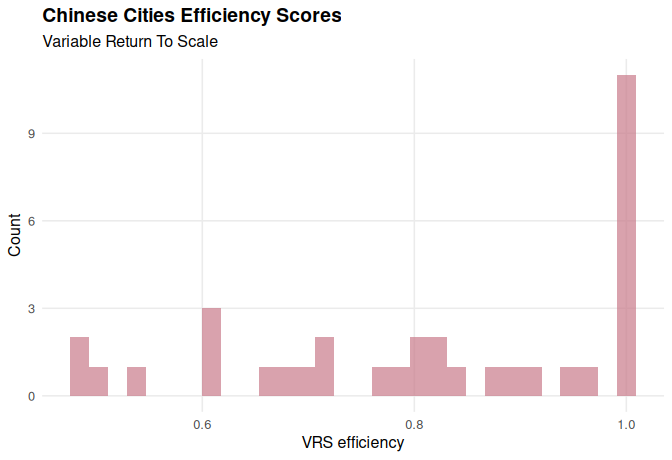

```r
plot_efficiency_distributions(d, rts = "vrs", title = "Chinese Cities Efficiency Scores", subtitle = "Variable Return To Scale")
```

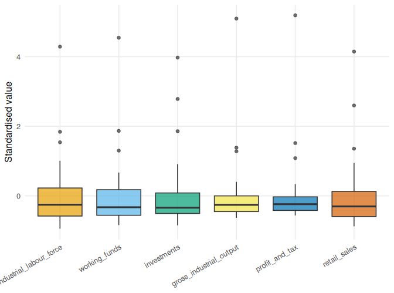

```r
plot_io_distributions(d, type = "box", x_angle = 30)
```

Note the use of `x_angle = 30`: because the input and output names are long, tilting the x-axis tick labels keeps them readable. Every plot that displays variable or DMU names on the x-axis accepts the `x_angle` argument.

The `plot_io_efficients()` function compares the number of efficient versus inefficient DMUs.

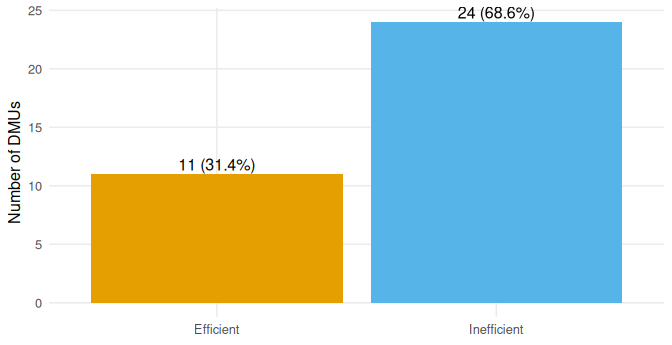

```r
plot_io_efficients(d, rts = "vrs", transparency = 1)
```

## Input/output relationships and the frontier

`plot_io_scatter()` lays out every input-against-output pair if no vector of inputs and/or outputs is assigned to `vars`. If a vector is provided, then the scatterplots will be limited to the pairwise combinations of those variables. Regardless, the visual marks are colored by efficiency.

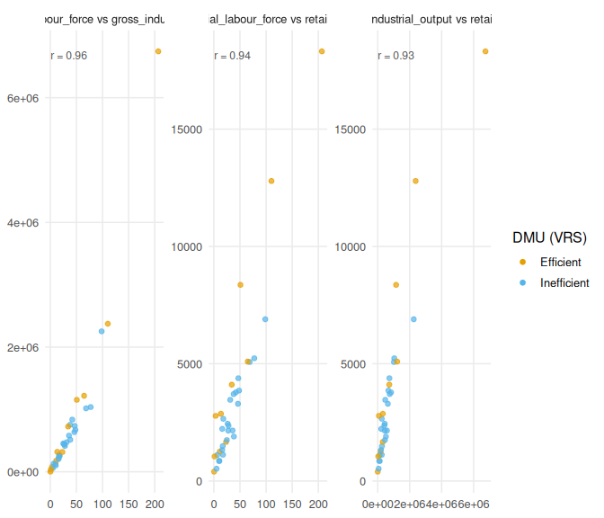

```r
plot_io_scatter(d, vars = c("industrial_labour_force", "gross_industrial_output", "retail_sales") , color = "vrs")
```

It is possible to plot scatterplots against the efficiency scores of the DMUs as well:

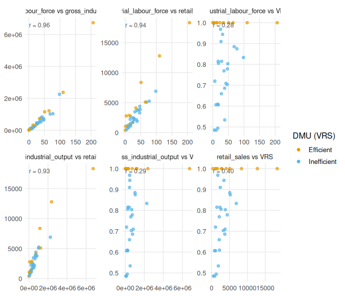

```r
plot_io_scatter(d, vars = c("industrial_labour_force", "gross_industrial_output", "retail_sales"), efficiency = "vrs" , color = "vrs")
```

## Frontier Visualization

The only frontier visualization plot available is via `plot_io_costa_frontier()`, which collapses all inputs and outputs onto a single aggregated frontier (Bana e Costa et al., 2016).

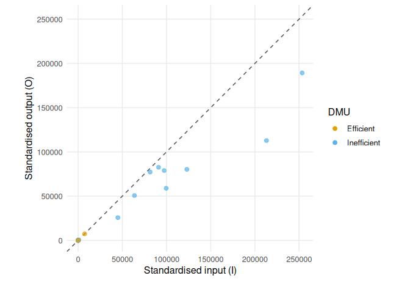

```r
plot_io_costa_frontier(d)
```

## Projection biplots

The package offers two ways to project the multidimensional input/output space onto a readable plane. First, `plot_io_pca_biplot()` uses Principal Component Analysis (PCA) to draw the input/output loading vectors. Second, `plot_io_mds()` uses metric (ratio) multidimensional scaling via the **smacof** majorization algorithm (de Leeuw & Mair, 2009). The graphical application of these projections to DEA follows Adler & Raveh (2008).

Let’s have a look at the PCA biplot:

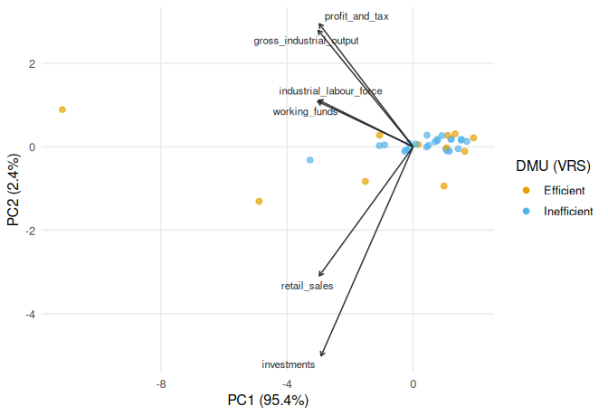

```r
plot_io_pca_biplot(d, rts = "vrs")
```

The vectors are the dataset’s inputs and outputs, and they show the direction in which the value of the corresponding input or output increases in the 2D space.

In contrast, we can use an MDS algorithm to reduce the dimensionality of the dataset and represent the DMUs visually in a 2D plot.

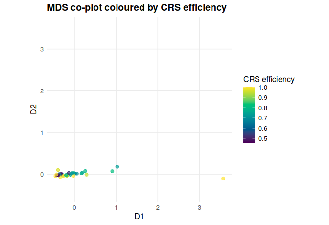

```r
plot_io_mds(d)
```

What to do with overcrowded plots? One solution offered by the `deaviz` package is to make the plot interactive so that you can zoom in and hover over the visual marks to get information about them.

```r
plot_io_mds(d, interactive = TRUE)
```

## Benchmarking networks

For inefficient DMUs, DEA identifies the efficient peers they are benchmarked against. `plot_io_lambda_network()` draws those peer relationships weighted by the envelopment ($\lambda$) weights, laid out with Sammon mapping (Sammon, 1969) as in Porembski et al. (2005). Meanwhile, `plot_io_peer_network()`lays out who is a peer to whom; therefore, the edges are directed from the inefficient units to their targets.

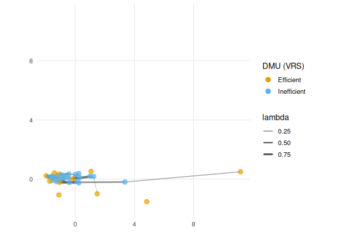

```r
plot_io_lambda_network(d, rts = "vrs")
```

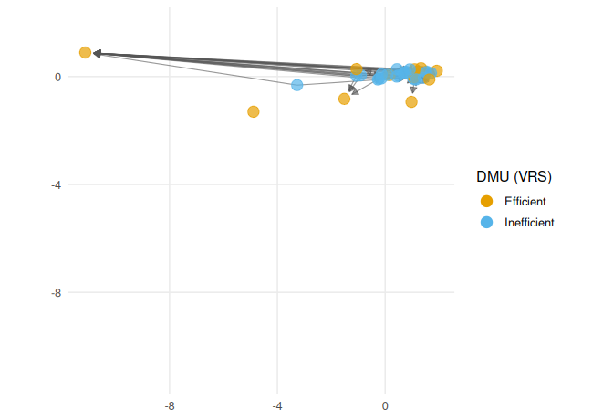

```r
plot_io_peer_network(d, rts = "vrs")
```

It is sometimes important in the networks to focus on and highlight a specific DMU and `deaviz` package addresses that need via the `labels =` argument:

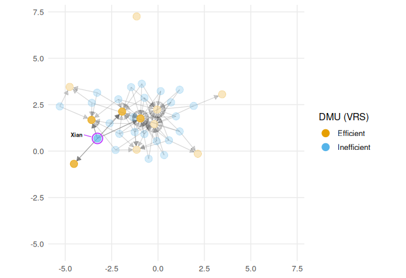

```r
plot_io_peer_network(d,layout = "fr",labels = "Xian", rts = "vrs")
```

## Cross-efficiency

Cross-efficiency scores every DMU using every other DMU’s optimal weights (Doyle & Green, 1994). `compute_cross_efficiency()` builds the matrix, which `plot_cem_heatmap()` displays. `plot_cem_unfolding()` unfolds the same matrix into a map of who rates whom favorably (Ashkiani & Mar-Molinero, 2017), and `plot_cem_weights_heatmap()` shows the underlying weight profiles.

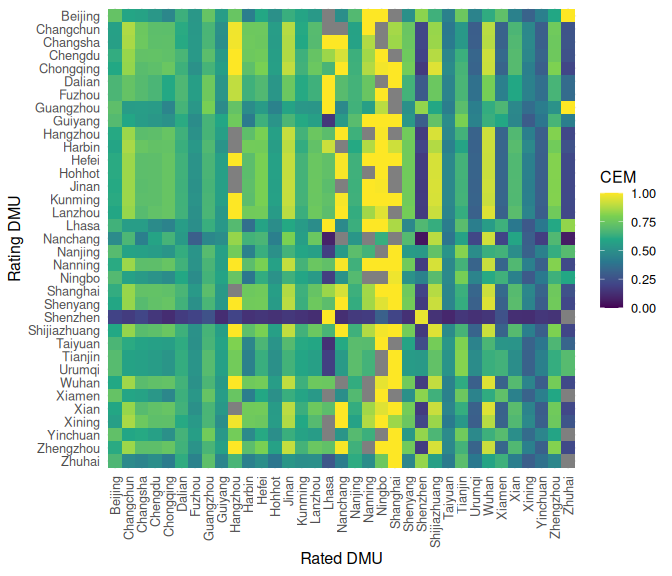

```r
cem <- compute_cross_efficiency(d)

plot_cem_heatmap(cem, x_angle = 90)
```

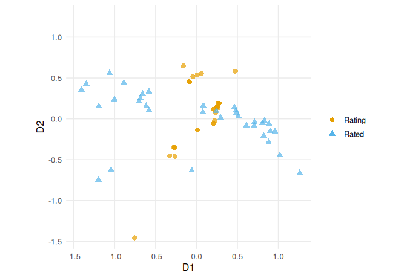

```r
plot_cem_unfolding(cem)
```

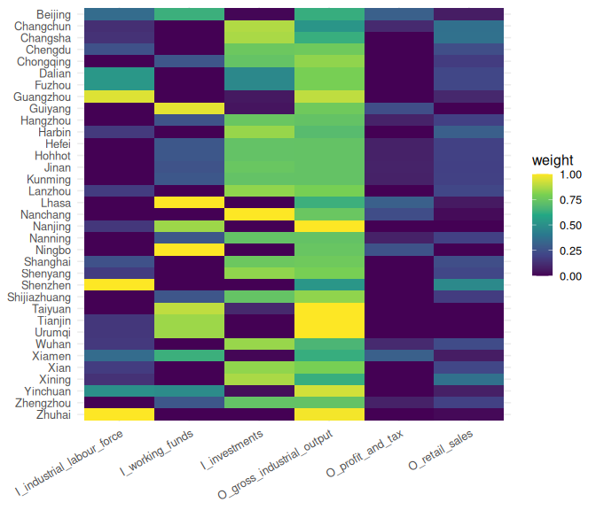

```r
plot_cem_weights_heatmap(d, x_angle = 30)
```

What if you want to highlight a specific DMU? Just as before, you can use the `labels` argument:

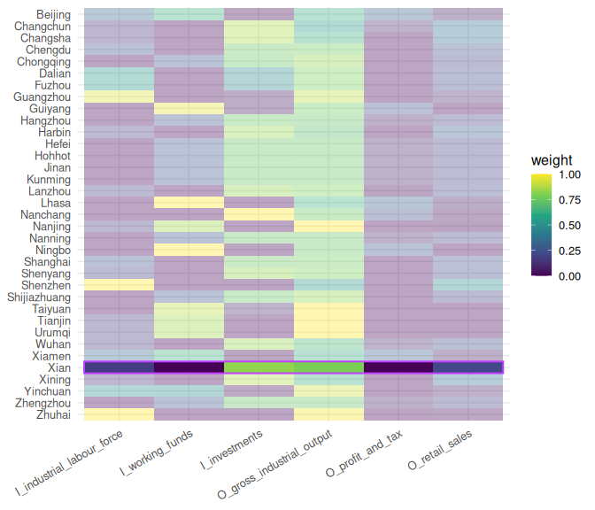

```r
plot_cem_weights_heatmap(d, x_angle = 30, labels = "Xian")
```

## Profile plots

`plot_io_radar()` and `plot_io_parcoo()` show each DMU’s full input/output profile as a radar polygon or a parallel-coordinates line.

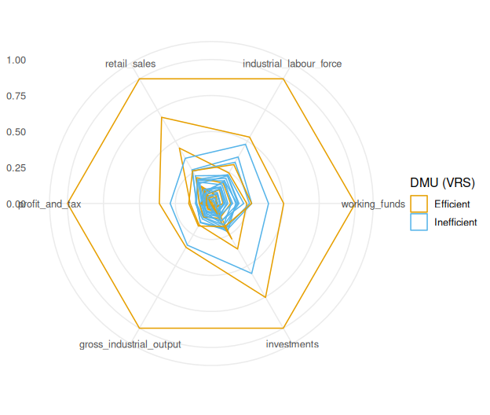

```r
plot_io_radar(d, efficiency = "vrs")
```

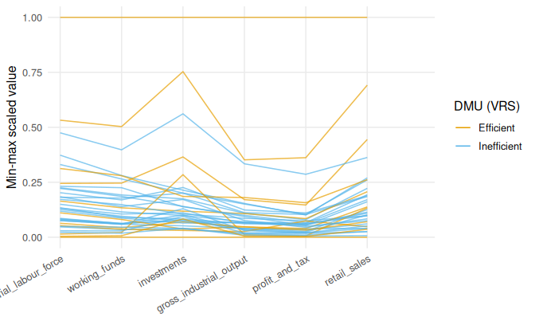

```r
plot_io_parcoo(d, efficiency = "vrs", x_angle = 30)
```

## Highlighting a single DMU: the focus view

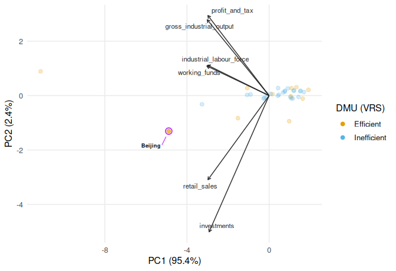

```r
plot_io_pca_biplot(d, rts = "vrs", labels = "Beijing")
```

The amount of fade is tunable through the `fade` argument: `TRUE` (default) uses a sensible level, `FALSE` turns it off, and a number sets the alpha of the faded marks directly (a larger number keeps them more visible).

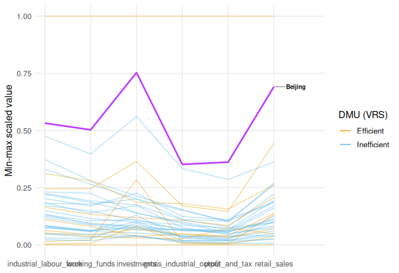

```r
plot_io_parcoo(d, efficiency = "vrs", labels = "Beijing", fade = 0.4)
```

Other `labels` modes are `"all"` (label everyone), `"id"` (number each marker), and `"max.overlaps"` (label as many as fit without collision).

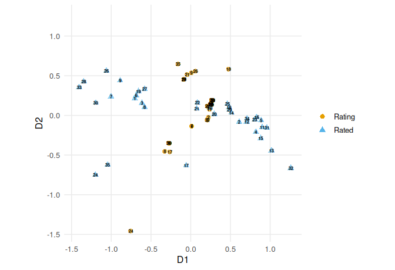

```r
plot_cem_unfolding(cem, labels = "id")
```

## Self-organising maps

`compute_som()` trains a self-organising map (Kohonen, 2001) on the input/output profiles, via the **kohonen** package (Wehrens & Kruisselbrink, 2018); `plot_io_som()` colours the map by mean efficiency per node.

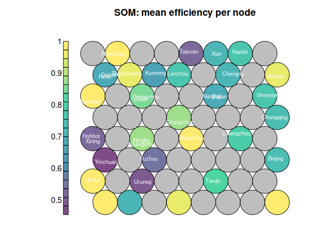

```r
som <- compute_som(d)
plot_io_som(som)
```

## Multi-period data: trajectories

For panel data, `plot_panel_io_biplot()` projects every DMU-period combination onto a shared PCA biplot and connects each DMU’s data points to form a trajectory over time. The bundled `taiwanese_banks` dataset provides a balanced panel of 22 commercial banks from 2009 to 2011 (Kao & Liu, 2014). This dataset serves as a reproducible benchmark to demonstrate the package’s panel functionality, regardless of the underlying input and output specifications. We can visualize these trajectories using the `deaviz` panel biplot while retaining all DMU identifiers on the plot:

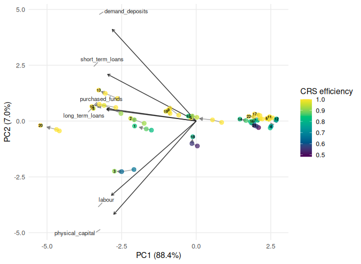

```r
plot_panel_io_biplot(
  taiwanese_banks, id = "DMU", period = "Year",
  inputs = 3:5, outputs = 6:8, labels = "id"
)
```

The trajectories, the paths that the DMUs have traversed based on their input/output profiles, are presented via the segmented vectors that connect each DMU’s position over the periods.

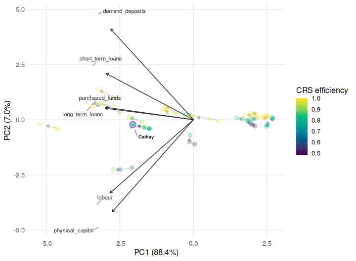

```r
plot_panel_io_biplot(
  taiwanese_banks, id = "DMU", period = "Year",
  inputs = 3:5, outputs = 6:8, labels = "Cathay", fade = 0.25
)
```

It is worth noting that the PCA is computed on the pooled data.

## Interactive plots

Many plots accept the `interactive = TRUE` argument, which returns a `plotly` widget with hover tooltips instead of a static `ggplot` object. This feature requires the `plotly` package and is best viewed within an HTML context:

```r
plot_io_pca_biplot(d, rts = "vrs", labels = "Beijing", interactive = TRUE)
```

## References

Adler, N., & Raveh, A. (2008). Presenting DEA graphically. *Omega*, 36(5), 715–729.

Ashkiani, S. (2019). *Four Essays on Data Visualization and Anomaly Detection of Data Envelopment Analysis Problems* (PhD thesis). Universitat Autonoma de Barcelona. https://ddd.uab.cat/record/240333

Ashkiani, S., & Mar-Molinero, C. (2017). Visualization of cross-efficiency matrices using multidimensional unfolding. In *Recent Applications of Data Envelopment Analysis*.

Bana e Costa, C. A., Soares de Mello, J. C. C. B., & Angulo Meza, L. (2016). A new approach to the bi-dimensional representation of the DEA efficient frontier with multiple inputs and outputs. *European Journal of Operational Research*, 255(1), 175–186. https://doi.org/10.1016/j.ejor.2016.05.012

Charnes, A., Cooper, W. W., & Rhodes, E. (1978). Measuring the efficiency of decision making units. *European Journal of Operational Research*, 2(6), 429–444. https://doi.org/10.1016/0377-2217(78)90138-8

de Leeuw, J., & Mair, P. (2009). Multidimensional scaling using majorization: SMACOF in R. *Journal of Statistical Software*, 31(3), 1–30. https://doi.org/10.18637/jss.v031.i03

Doyle, J., & Green, R. (1994). Efficiency and cross-efficiency in DEA: Derivations, meanings and uses. *Journal of the Operational Research Society*, 45(5), 567–578. https://doi.org/10.1057/jors.1994.84

Kao, C., & Liu, S.-T. (2014). Multi-period efficiency measurement in data envelopment analysis: The case of Taiwanese commercial banks. *Omega*, 47, 90–98. https://doi.org/10.1016/j.omega.2013.09.001

Kohonen, T. (2001). *Self-Organizing Maps* (3rd ed.). Springer.

Porembski, M., Breitenstein, K., & Alpar, P. (2005). Visualizing efficiency and reference relations in data envelopment analysis with an application to the branches of a German bank. *Journal of Productivity Analysis*, 23(2), 203–221. https://doi.org/10.1007/s11123-005-1328-5

Sammon, J. W. (1969). A nonlinear mapping for data structure analysis. *IEEE Transactions on Computers*, C-18(5), 401–409. https://doi.org/10.1109/T-C.1969.222678

Sueyoshi, T. (1992). Measuring the industrial performance of Chinese cities by data envelopment analysis. *Socio-Economic Planning Sciences*, 26(2), 75–88. https://doi.org/10.1016/0038-0121(92)90015-W

Wehrens, R., & Kruisselbrink, J. (2018). Flexible self-organizing maps in kohonen 3.0. *Journal of Statistical Software*, 87(7), 1–18. https://doi.org/10.18637/jss.v087.i07

## Where to next

Every function has its own help page with a full argument list and examples (e.g. `?plot_panel_io_biplot`). To cite the package, see `citation("deaviz")`.